# 語言與性別

June 7, 2018

## 背景

- 對話主角：我的父母
  - 父親：57歲
  - 母親：55歲
- 地點：家裡客廳
- 時間：22:30 左右
- 錄音長度：1 分 49 秒
- 話題背景：父親上午處理祖母的房子買賣，和母親談論到房仲業者。

## 錄音檔

[interactive chart not shown]

[錄音](https://drive.google.com/file/d/1rgyKmlQu0aW_5w4r6X8WVF1xqEwlAgmt/view?usp=sharing)

## 表格

| 身份 | 總長度(秒) | 說話(次) | 平均長度(秒) |
| --- | --- | --- | --- |
| 父 | 70.00 | 29 | 2.41 |
| 母 | 19.96 | 11 | 1.81 |

說話者轉換次數：12

## 圖

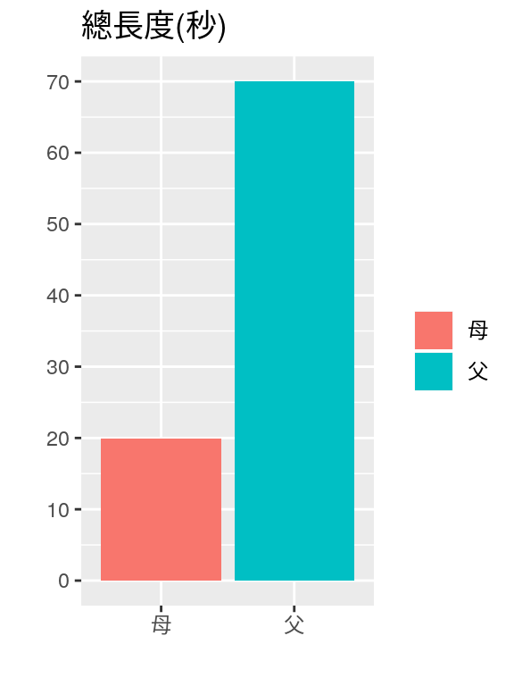

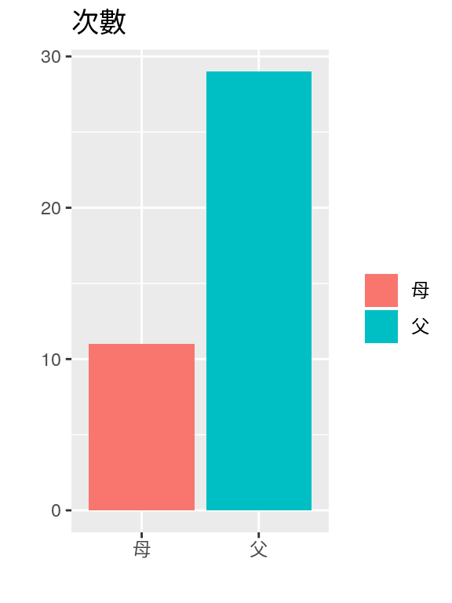

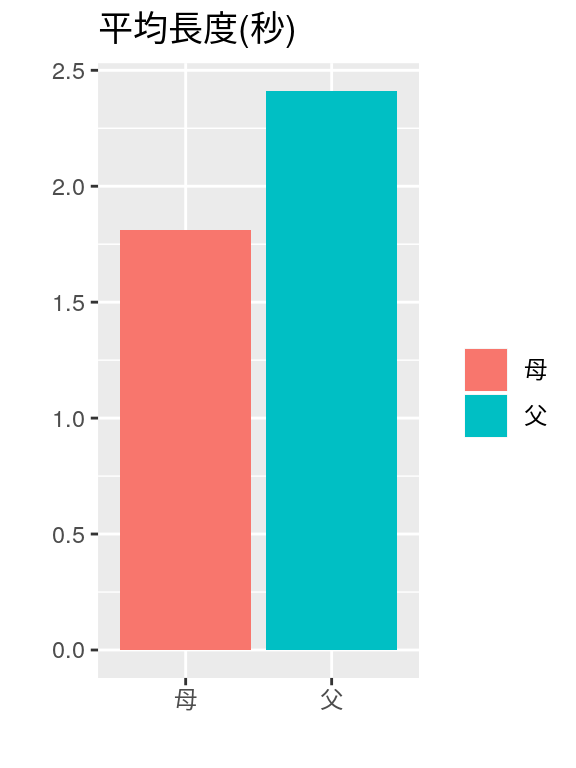

說話者轉換次數：12

## 討論(此錄音)

- 父親
  - 話多(時間是母親的 3.5 倍)
  - 陳述、回答為主
  - 佔話題主動、支配地位
- 母親
  - 話少且短(每句話平均時間較短)
  - 提問為主
  - 聆聽、資訊接受者
- 原因：對話主題造成？
  - 父親握有話題相關資訊(講述他的經歷)
  - (所以？)父親掌握話題主導權

## 討論(日常對話)

- 父親
  - 話多(長度長)：對母親、姐姐、我、外人皆成立
  - 喜歡掌握話題、說話時常居**主導地位**
- 母親
  - 與父親對話時，常居於**被動**、**資訊接收者**
    - 主題非日常涉獵範圍、沒興趣
    - 例外：
      - 主題為「財經」、「股票」等(共同興趣)：說話時間、主動程度上升
      - 主題為「保險」(母親行業)：居主導地位

## 討論(與讀本比較)

|  | 公共場合 | 私人場合 |
| --- | --- | --- |
| 男 | 話多 / 報告式談話 | 話少 |
| 女 | 話少 | 話多 / 情感式談話 |

- 報告式談話：
  - > (男人)展示自己高人一等的知識與才能，就著說故事、說笑話以及提供資訊等方式，將自己推向舞台的中心 —《男女親密對話》p.70
- 父親
  - 偏好報告式談話
  - 公、私場合：皆話多、偏好報告式談話
- 母親：無法歸類於表格中
  - 報告式、情感式談話：無偏好差別
  - 公、私場合上無差異